# STAT 331 Portfolio

Author

Noor Karaki

**My Grade:** I believe my grade equivalent to course work evidenced below to be an A-.

**Learning Objective Evidence:** In the code chunks below, provide code from Lab or Challenge assignments where you believe you have demonstrated proficiency with the specified learning target. Be sure to specify **where** the code came from (e.g., Lab 4 Question 2).

## Working with Data

**WD-1: I can import data from a *variety* of formats (e.g., csv, xlsx, txt, etc.).**

- `csv`

```r
childcare_data <- read_csv(here("data", "childcare_costs.csv"))
#Code from Lab 3, Set up step
```

- `xlsx`

```r
agesxl <- real_xlsx(path = here::here("check-ins", "2.3-loading-data", "Ages_Data", "ages.xlsx"), sheet = "ages")
#Check-in 2.3 Importing Data
```

- `txt`

```r
ages_tab <- read_table(file = here::here("Week 2","Check-ins","Ages_Data","ages_tab.txt"))
#Check-in 2.3 Importing Data
```

**WD-2: I can select necessary columns from a dataset.**

```r
teacher_evals_clean <- teacher_evals %>%
  rename(sex = gender) %>%
  filter(no_participants >= 10) %>%
  mutate(
    across(
      c(teacher_id,
        course_id),
           as.character))%>%
  select(course_id,
         teacher_id,
         question_no,
         no_participants,
         resp_share,
         SET_score_avg,
         percent_failed_cur,
         academic_degree,
         seniority,
         sex)
#Code from Lab 3, Problem 5
```

Reflection: This selection demonstrates the ability to efficiently isolate relevant columns for analysis, ensuring clarity and precision and fluidly load in different types of data sets.

**WD-3: I can filter rows from a dataframe for a *variety* of data types (e.g., numeric, integer, character, factor, date).**

- numeric

```r
teacher_evals_clean <- teacher_evals %>%
  rename(sex = gender) %>%
  filter(no_participants >= 10) %>%
  mutate(
    across(
      c(teacher_id,
        course_id),
           as.character))%>%
  select(course_id,
         teacher_id,
         question_no,
         no_participants,
         resp_share,
         SET_score_avg,
         percent_failed_cur,
         academic_degree,
         seniority,
         sex)
#Code from Lab 3, Problem 5
```

- character – specifically a string (example must use functions from **stringr**)

```r
#Revised version
 person %>%
  # Filter for rows that match either witness condition
  filter(
    (address_street_name == "Northwestern Dr" & address_number == max(address_number)) |
    (str_detect(name, "^Annabel") & address_street_name == "Franklin Ave")
  ) %>%
    inner_join(interview, by = c("id" = "person_id")) %>%
 person
#Code from Lab 5, Problem 2
#The feedback you gave me included not needing to find the max address and save it as an object first and rather could calculate it inside the filter() and check if the address_number is equal to the max. And to collapse my steps into one pipeline. Also used the caret (^) to indicate that the match is at the start of the string
```

- factor

```r
ca_childcare <- ca_childcare |>
  mutate(region = fct_collapse(county_name,
                               `Superior California` = c("Butte County",
                                                         "Colusa County",
                                                         "El Dorado County",
                                                         "Glenn County",
                                                         "Lassen County",
                                                         "Modoc County",
                                                         "Nevada County",
                                                         "Placer County",
                                                         "Plumas County",
                                                         "Sacramento County",
                                                         "Shasta County",
                                                         "Sierra County",
                                                         "Siskiyou County",
                                                         "Sutter County",
                                                         "Tehama County",
                                                         "Yolo County",
                                                         "Yuba County"),
                               `North Coast` = c("Del Norte County",
                                                 "Humboldt County",
                                                 "Lake County",
                                                 "Mendocino County",
                                                 "Napa County",
                                                 "Sonoma County",
                                                 "Trinity County"),
                               `San Francisco Bay Area` = c("Alameda County",
                                                            "Contra Costa County",
                                                            "Marin County",
                                                            "San Francisco County",
                                                            "San Mateo County",
                                                            "Santa Clara County",
                                                            "Solano County"),
                               `Northern San Joaquin Valley` = c("Alpine County",
                                                                 "Amador County",
                                                                 "Calaveras County",
                                                                 "Madera County",
                                                                 "Mariposa County",
                                                                 "Merced County",
                                                                 "Mono County",
                                                                 "San Joaquin County",
                                                                 "Stanislaus County",
                                                                 "Tuolumne County"),
                               `Central Coast` = c("Monterey County",
                                                   "San Benito County",
                                                   "San Luis Obispo County",
                                                   "Santa Barbara County",
                                                   "Santa Cruz County",
                                                   "Ventura County"),
                               `Southern San Joaquin Valley` = c("Fresno County",
                                                                 "Inyo County",
                                                                 "Kern County",
                                                                 "Kings County",
                                                                 "Tulare County"),
                               `Inland Empire` = c("Riverside County",
                                                   "San Bernardino County"),
                               `Los Angeles County` = c("Los Angeles County"),
                               `Orange County` = c("Orange County"),
                               `San Diego - Imperial` = c("Imperial County",
                                                          "San Diego County")
                                )
         )
#Code from Lab 4, Problem 3
```

- date (example must use functions from **lubridate**)

```r
crime_scene_report <- crime_scene_report %>%
  mutate(date = ymd(date)) %>%
    filter(
    year(date) == 2018,
    month(date) == 1,
    day(date) == 15,
    city == "SQL City",
    type == "murder"
  ) %>%
  pull(description)
crime_scene_report
#Code from Lab 5 Number 1
#This code is revised, the feedback you gave me included to filter to only include murder reports and to use a comma in the filter if I want both conditions satisfyed. Also revised from midterm porfolio included other functions to make the serach more complex instead of only using the ymd().
```

**Reflection:** Filtering data by numeric and factor types has been essential in narrowing datasets to areas of interest and eliminating irrelevant data.

**WD-4: I can modify existing variables and create new variables in a dataframe for a *variety* of data types (e.g., numeric, integer, character, factor, date).**

- numeric (using `as.numeric()` is not sufficient)

```r
library(dplyr)
teacher_evals_compare <- teacher_evals %>%
  filter(question_no == 903) %>%
  mutate(
    SET_level = if_else(SET_score_avg >= 4, "excellent", "standard"),
    sen_level = if_else(seniority <= 4, "junior", "senior")
  ) %>%
  select(course_id, SET_level, sen_level)
teacher_evals_compare
#Code from Challenge 3, Problem 1
```

- character – specifically a string (example must use functions from **stringr**)

```r
library(dplyr)
library(stringr)
#revised code to use stringr package
teacher_evals_clean <- teacher_evals %>%
  rename(sex = gender) %>%
  filter(no_participants >= 10) %>%
  mutate(
    # Convert columns to character and format using stringr
    teacher_id = str_pad(as.character(teacher_id), width = 5, pad = "0"),
    course_id = str_to_upper(as.character(course_id))
  ) %>%
  select(course_id,
         teacher_id,
         question_no,
         no_participants,
         resp_share,
         SET_score_avg,
         percent_failed_cur,
         academic_degree,
         seniority,
         sex)
#Code from Lab 3, Problem 5
```

- factor (example must use functions from **forcats**)

```r
ca_childcare <- ca_childcare |>
  mutate(region = fct_collapse(county_name,
                               `Superior California` = c("Butte County",
                                                         "Colusa County",
                                                         "El Dorado County",
                                                         "Glenn County",
                                                         "Lassen County",
                                                         "Modoc County",
                                                         "Nevada County",
                                                         "Placer County",
                                                         "Plumas County",
                                                         "Sacramento County",
                                                         "Shasta County",
                                                         "Sierra County",
                                                         "Siskiyou County",
                                                         "Sutter County",
                                                         "Tehama County",
                                                         "Yolo County",
                                                         "Yuba County"),
                               `North Coast` = c("Del Norte County",
                                                 "Humboldt County",
                                                 "Lake County",
                                                 "Mendocino County",
                                                 "Napa County",
                                                 "Sonoma County",
                                                 "Trinity County"),
                               `San Francisco Bay Area` = c("Alameda County",
                                                            "Contra Costa County",
                                                            "Marin County",
                                                            "San Francisco County",
                                                            "San Mateo County",
                                                            "Santa Clara County",
                                                            "Solano County"),
                               `Northern San Joaquin Valley` = c("Alpine County",
                                                                 "Amador County",
                                                                 "Calaveras County",
                                                                 "Madera County",
                                                                 "Mariposa County",
                                                                 "Merced County",
                                                                 "Mono County",
                                                                 "San Joaquin County",
                                                                 "Stanislaus County",
                                                                 "Tuolumne County"),
                               `Central Coast` = c("Monterey County",
                                                   "San Benito County",
                                                   "San Luis Obispo County",
                                                   "Santa Barbara County",
                                                   "Santa Cruz County",
                                                   "Ventura County"),
                               `Southern San Joaquin Valley` = c("Fresno County",
                                                                 "Inyo County",
                                                                 "Kern County",
                                                                 "Kings County",
                                                                 "Tulare County"),
                               `Inland Empire` = c("Riverside County",
                                                   "San Bernardino County"),
                               `Los Angeles County` = c("Los Angeles County"),
                               `Orange County` = c("Orange County"),
                               `San Diego - Imperial` = c("Imperial County",
                                                          "San Diego County")
                                )
         )
#creating the variable "region"
#Code from Lab 4 Number 3
```

- date (example must use functions from **lubridate**)

```r
crime_scene_report <- crime_scene_report %>%
  mutate(date = ymd(date)) %>%
    filter(
    year(date) == 2018,
    month(date) == 1,
    day(date) == 15,
    city == "SQL City",
    type == "murder"
  ) %>%
  pull(description)
crime_scene_report

#modifying the date variaible
#Code from Lab 5 Number 1
#This code is revised, the feedback you gave me included to filter to only include murder reports and to use a comma in the filter if I want both conditions satisfyed.
```

**WD-5: I can use mutating joins to combine multiple dataframes.**

- `left_join()`

```r
final_suspect <- facebook_event_checkin %>%
  inner_join(person, by = join_by(person_id == id)) %>%
  inner_join(drivers_license, by = join_by(license_id == id)) %>%
  filter(
    hair_color == "red",
    car_make == "Tesla",
    car_model == "Model S",
    event_name == "SQL Symphony Concert"
  ) %>%
  # using left_join to bring in transcripts
  left_join(interview, by = join_by(person_id == person_id))

final_suspect
#lab 5 in my revisions last step
```

- `right_join()`
- `inner_join()`

```r
#Revised version
 person %>%
  # Filter for rows that match either witness condition
  filter(
    (address_street_name == "Northwestern Dr" & address_number == max(address_number)) |
    (str_detect(name, "^Annabel") & address_street_name == "Franklin Ave")
  ) %>%
    inner_join(interview, by = c("id" = "person_id")) %>%
 person
#Code from Lab 5, Problem 2
#The feedback you gave me included not needing to find the max address and save it as an object first and rather could calculate it inside the filter() and check if the address_number is equal to the max. And to collapse my steps into one pipeline.
```

**WD-6: I can use filtering joins to filter rows from a dataframe.**

- `semi_join()`

```r
#revised my code here to use semi_join() instead of %in% but since i was looking into a column and not a full dataframe i created the academic_degree into its own tibble

# creating small datafram called degree_lookup, with single column named academic_degree which has values "dr" "prof"
degree_lookup <- tibble(academic_degree = c("dr", "prof"))

teacher_evals_clean %>%
  # keeps only rows in teacher_evals_clean where academic_degree column matches a value in the degree_lookup table
  semi_join(degree_lookup, by = "academic_degree") %>%
  filter(sex == "female") %>%
  #group by teacher_id to compute average response share
  group_by(teacher_id) %>%
  summarize(
    avg_resp_share = mean(resp_share, na.rm = TRUE)
  ) %>%
  # filter for teachers with the min or max avg_resp_share
  filter(
    avg_resp_share == min(avg_resp_share) | avg_resp_share == max(avg_resp_share)
  )
# Code from Lab 3 question 12, revised to use semi_join and output not just one teacher each
```

- `anti_join()`

**WD-7: I can pivot dataframes from long to wide and visa versa**

- `pivot_longer()`

```r
library(ggplot2)
library(RColorBrewer)

mycolors <- colorRampPalette(brewer.pal(8, "Accent"))(10)
#Revised plot
childcare_costs_plot <- ca_childcare %>%
  # Filtering to include only 2008 and later years
  filter(study_year >= 2008) %>%

  # Pivoting the data to a long format for the age groups
  pivot_longer(cols = c(mc_infant,
                        mc_toddler,
                        mc_preschool),
               names_to = "age_group",
               values_to = "median_price") %>%
  mutate(age_group = fct_recode(age_group,
                                "Infant" = "mc_infant",
                                "Toddler" = "mc_toddler",
                                "Preschool" = "mc_preschool"),
         age_group = fct_relevel(age_group,
                                 "Infant",
                                 "Toddler",
                                 "Preschool"),
         median_price = as.numeric(median_price)) %>%

  # Creating the ggplot object
  ggplot(aes(x = study_year,
             y = median_price,
             color = fct_reorder2(.f = region,
                                  .x = study_year,
                                  .y = median_price))) +

   # Adding points for each data value
  geom_point(size = 0.5) +

  # Adding a smooth line for each region and shows standard error shading
  geom_smooth(method = "loess",
              se = TRUE) +

  # Faceting the plot by age group (Infant, Toddler, Preschool)
  facet_wrap(~ age_group) +
  theme_bw() +

  # Adjusting colors and other aesthetic options
  scale_color_manual(values = mycolors) +
  labs(title = "Weekly Median Price for Center-Based Childcare ($)",
       x = "Study Year",
       y = " ",
       color = "California Region") +

  # scale_x_continuous: changes the x-axis when its a continuous numeric value (year)
  # breaks = seq(start, end, # of increments) controls where the tick marks and labels show
  scale_x_continuous(breaks = seq(2008,
                                  2018,
                                  by = 2)) +
  scale_y_continuous(limits = c(100,
                                500),
                     breaks = seq(100,
                                  500,
                                 by = 100)) +

  # Customizing
  theme(
    plot.title = element_text(hjust = 0.5,
                              face = "bold"),               # Centers title and bold
    legend.position = "right",                              # Place the legend on the right
    legend.text = element_text(size = 7),                   # Adjust legend text size
    legend.title = element_text(size = 9),                  # Adjust legend title size
    legend.key.size = unit(1,
                           "lines"),                        # Adjust the size of the legend keys
    legend.key.height = unit(0.7,
                             "lines"),                      # Compact height of each legend key
    strip.text = element_text(face = "bold"),               # Making the facet titles bold
    axis.title.x = element_text(size = 10),                 # Adjust x-axis title
    axis.text = element_text(size = 6),                     # Adjust both axis text size
    aspect.ratio = 1                                        # This makes each facet square-like
  )

childcare_costs_plot
#Code from Lab 4, Problem 6
```

- `pivot_wider()`

```r
median_income_table <- ca_childcare %>%
  filter(study_year %in% c(2008,
                           2018)) %>%
  group_by(region,
           study_year) %>%
  #added the .groups = "drop" - revision
  summarize(median_income = median(mhi_2018,
                                   na.rm = TRUE,
                                   .groups = "drop")) %>%
  pivot_wider(names_from = study_year,
              values_from = median_income,
              names_prefix = "Income_") %>%
  arrange(Income_2018)

median_income_table
#Code from Lab 4, Problem 4
```

## Reproducibility

**R-1: I can create professional looking, reproducible analyses using RStudio projects, Quarto documents, and the here package.**

I’ve done this in the following provided assignments: I have used the here package consistently when given a data file to download and load in manually which includes for example Lab 3 setup below:

```r
childcare_data <- read_csv(here("data", "childcare_costs.csv"))
#Code from Lab 3, Set up step
```

**R-2: I can write well documented and tidy code.**

- Example of **ggplot2** plotting

```r
# Creating a scatterplot with clear labels and theme for readability
ggplot(ca_childcare,
       aes(x = mhi_2018,
           y = mc_infant)) +
  geom_point() +
  geom_smooth(method = "lm",
              se = FALSE,
              color = "blue") +
  labs(title = "Childcare Costs for Infants",
       x = "Median Household Income (2018 Dollars)",
       y = "Full-time Median Weekly Price for Infants") +
  theme_minimal()
#Code from Lab 4, Problem 7
```

- Example of **dplyr** pipeline

```r
library(ggplot2)
library(RColorBrewer)

mycolors <- colorRampPalette(brewer.pal(8, "Accent"))(10)
#Revised plot
childcare_costs_plot <- ca_childcare %>%
  # Filtering to include only 2008 and later years
  filter(study_year >= 2008) %>%

  # Pivoting the data to a long format for the age groups
  pivot_longer(cols = c(mc_infant,
                        mc_toddler,
                        mc_preschool),
               names_to = "age_group",
               values_to = "median_price") %>%
  mutate(age_group = fct_recode(age_group,
                                "Infant" = "mc_infant",
                                "Toddler" = "mc_toddler",
                                "Preschool" = "mc_preschool"),
         age_group = fct_relevel(age_group,
                                 "Infant",
                                 "Toddler",
                                 "Preschool"),
         median_price = as.numeric(median_price)) %>%

  # Creating the ggplot object
  ggplot(aes(x = study_year,
             y = median_price,
             color = fct_reorder2(.f = region,
                                  .x = study_year,
                                  .y = median_price))) +

   # Adding points for each data value
  geom_point(size = 0.5) +

  # Adding a smooth line for each region and shows standard error shading
  geom_smooth(method = "loess",
              se = TRUE) +

  # Faceting the plot by age group (Infant, Toddler, Preschool)
  facet_wrap(~ age_group) +
  theme_bw() +

  # Adjusting colors and other aesthetic options
  scale_color_manual(values = mycolors) +
  labs(title = "Weekly Median Price for Center-Based Childcare ($)",
       x = "Study Year",
       y = " ",
       color = "California Region") +

  # scale_x_continuous: changes the x-axis when its a continuous numeric value (year)
  # breaks = seq(start, end, # of increments) controls where the tick marks and labels show
  scale_x_continuous(breaks = seq(2008,
                                  2018,
                                  by = 2)) +
  scale_y_continuous(limits = c(100,
                                500),
                     breaks = seq(100,
                                  500,
                                 by = 100)) +

  # Customizing
  theme(
    plot.title = element_text(hjust = 0.5,
                              face = "bold"),               # Centers title and bold
    legend.position = "right",                              # Place the legend on the right
    legend.text = element_text(size = 7),                   # Adjust legend text size
    legend.title = element_text(size = 9),                  # Adjust legend title size
    legend.key.size = unit(1,
                           "lines"),                        # Adjust the size of the legend keys
    legend.key.height = unit(0.7,
                             "lines"),                      # Compact height of each legend key
    strip.text = element_text(face = "bold"),               # Making the facet titles bold
    axis.title.x = element_text(size = 10),                 # Adjust x-axis title
    axis.text = element_text(size = 6),                     # Adjust both axis text size
    aspect.ratio = 1                                        # This makes each facet square-like
  )

childcare_costs_plot
#Code from Lab 4 Problem 6
```

- Example of function formatting

```r
library(ggplot2)
library(RColorBrewer)

mycolors <- colorRampPalette(brewer.pal(8, "Accent"))(10)
#Revised plot
childcare_costs_plot <- ca_childcare %>%
  # Filtering to include only 2008 and later years
  filter(study_year >= 2008) %>%

  # Pivoting the data to a long format for the age groups
  pivot_longer(cols = c(mc_infant,
                        mc_toddler,
                        mc_preschool),
               names_to = "age_group",
               values_to = "median_price") %>%
  mutate(age_group = fct_recode(age_group,
                                "Infant" = "mc_infant",
                                "Toddler" = "mc_toddler",
                                "Preschool" = "mc_preschool"),
         age_group = fct_relevel(age_group,
                                 "Infant",
                                 "Toddler",
                                 "Preschool"),
         median_price = as.numeric(median_price)) %>%

  # Creating the ggplot object
  ggplot(aes(x = study_year,
             y = median_price,
             color = fct_reorder2(.f = region,
                                  .x = study_year,
                                  .y = median_price))) +

   # Adding points for each data value
  geom_point(size = 0.5) +

  # Adding a smooth line for each region and shows standard error shading
  geom_smooth(method = "loess",
              se = TRUE) +

  # Faceting the plot by age group (Infant, Toddler, Preschool)
  facet_wrap(~ age_group) +
  theme_bw() +

  # Adjusting colors and other aesthetic options
  scale_color_manual(values = mycolors) +
  labs(title = "Weekly Median Price for Center-Based Childcare ($)",
       x = "Study Year",
       y = " ",
       color = "California Region") +

  # scale_x_continuous: changes the x-axis when its a continuous numeric value (year)
  # breaks = seq(start, end, # of increments) controls where the tick marks and labels show
  scale_x_continuous(breaks = seq(2008,
                                  2018,
                                  by = 2)) +
  scale_y_continuous(limits = c(100,
                                500),
                     breaks = seq(100,
                                  500,
                                 by = 100)) +

  # Customizing
  theme(
    plot.title = element_text(hjust = 0.5,
                              face = "bold"),               # Centers title and bold
    legend.position = "right",                              # Place the legend on the right
    legend.text = element_text(size = 7),                   # Adjust legend text size
    legend.title = element_text(size = 9),                  # Adjust legend title size
    legend.key.size = unit(1,
                           "lines"),                        # Adjust the size of the legend keys
    legend.key.height = unit(0.7,
                             "lines"),                      # Compact height of each legend key
    strip.text = element_text(face = "bold"),               # Making the facet titles bold
    axis.title.x = element_text(size = 10),                 # Adjust x-axis title
    axis.text = element_text(size = 6),                     # Adjust both axis text size
    aspect.ratio = 1                                        # This makes each facet square-like
  )

childcare_costs_plot
#Code from Lab 4 Problem 6
```

**R-3: I can write robust programs that are resistant to changes in inputs.**

- Example – any context

```r
lowest_price_region <- ca_childcare %>%
  filter(study_year == 2018) %>%
  group_by(region) %>%
  summarize(median_price = median(mc_infant,
                                  na.rm = TRUE)) %>%
  slice_min(median_price,
            n = 1)

lowest_price_region

#Code from Lab 4, Problem 5
```

- Example of function stops

```r
rescale_01 <- function(x) {
  if(!is.numeric(x)) stop("Input vector must be numeric")
  if(length(x) <= 1) stop("input vector must have more than one element")
  #uses range to get the min and max values
  rng <- range(x, na.rm = TRUE)
  #rescales using the range and returns the result
  (x - rng[1]) / (rng[2] - rng[1])
}
#Code from Lab 7 question 4
```

## Data Visualization & Summarization

**DVS-1: I can create visualizations for a *variety* of variable types (e.g., numeric, character, factor, date)**

- at least two numeric variables

```r
# Scatterplot with linear regression to show relationship
ca_childcare %>%
  ggplot(aes(x = mhi_2018, y = mc_infant)) +
  geom_point() +
  geom_smooth(method = "lm", se = FALSE, color = "blue") +
  labs(title = "Childcare Costs for Infants",
       x = "Median Household Income (2018 Dollars)",
       y = "Full-time Median Weekly Price for Infants") +
  theme_minimal()
#Code from Lab 4, Problem 7
```

- at least one numeric variable and one categorical variable

```r
library(ggridges)
#| label: ridge plot
ggplot(data = surveys, aes(x = weight,
                           y = species)) +
  geom_density_ridges(fill = "pink", color = "black", alpha = 0.7, bandwidth = 1) +
  labs(x = "Weight (grams)",
       y = "",
       title = "Distribution of Different Rodent Sizes",
       subtitle = "Species")
#Code from Challenge 2
```

- at least two categorical variables

```r
# code chunk for Q2
library(ggplot2)

ggplot(
  teacher_evals_compare,
  aes(x = sen_level,
      fill = SET_level)) +
  geom_bar() +
  labs(
    x = "Seniority of Instructor",
    y = "",
    title = "SET Ratings Comparison by Seniority",
    subtitle = "Number of Sections"
  ) +
  scale_fill_manual(values = c("excellent" = "steelblue",
                               "standard" = "orange3"))
#categorigal variables include SET_level and Seniority of Instructor
#Code from Challenge 3 Problem 2
```

- dates (timeseries plot)

```r
library(ggplot2)
library(RColorBrewer)

mycolors <- colorRampPalette(brewer.pal(8, "Accent"))(10)
#Revised plot
childcare_costs_plot <- ca_childcare %>%
  # Filtering to include only 2008 and later years
  filter(study_year >= 2008) %>%

  # Pivoting the data to a long format for the age groups
  pivot_longer(cols = c(mc_infant,
                        mc_toddler,
                        mc_preschool),
               names_to = "age_group",
               values_to = "median_price") %>%
  mutate(age_group = fct_recode(age_group,
                                "Infant" = "mc_infant",
                                "Toddler" = "mc_toddler",
                                "Preschool" = "mc_preschool"),
         age_group = fct_relevel(age_group,
                                 "Infant",
                                 "Toddler",
                                 "Preschool"),
         median_price = as.numeric(median_price)) %>%

  # Creating the ggplot object
  ggplot(aes(x = study_year,
             y = median_price,
             color = fct_reorder2(.f = region,
                                  .x = study_year,
                                  .y = median_price))) +

   # Adding points for each data value
  geom_point(size = 0.5) +

  # Adding a smooth line for each region and shows standard error shading
  geom_smooth(method = "loess",
              se = TRUE) +

  # Faceting the plot by age group (Infant, Toddler, Preschool)
  facet_wrap(~ age_group) +
  theme_bw() +

  # Adjusting colors and other aesthetic options
  scale_color_manual(values = mycolors) +
  labs(title = "Weekly Median Price for Center-Based Childcare ($)",
       x = "Study Year",
       y = " ",
       color = "California Region") +

  # scale_x_continuous: changes the x-axis when its a continuous numeric value (year)
  # breaks = seq(start, end, # of increments) controls where the tick marks and labels show
  scale_x_continuous(breaks = seq(2008,
                                  2018,
                                  by = 2)) +
  scale_y_continuous(limits = c(100,
                                500),
                     breaks = seq(100,
                                  500,
                                 by = 100)) +

  # Customizing
  theme(
    plot.title = element_text(hjust = 0.5,
                              face = "bold"),               # Centers title and bold
    legend.position = "right",                              # Place the legend on the right
    legend.text = element_text(size = 7),                   # Adjust legend text size
    legend.title = element_text(size = 9),                  # Adjust legend title size
    legend.key.size = unit(1,
                           "lines"),                        # Adjust the size of the legend keys
    legend.key.height = unit(0.7,
                             "lines"),                      # Compact height of each legend key
    strip.text = element_text(face = "bold"),               # Making the facet titles bold
    axis.title.x = element_text(size = 10),                 # Adjust x-axis title
    axis.text = element_text(size = 6),                     # Adjust both axis text size
    aspect.ratio = 1                                        # This makes each facet square-like
  )

childcare_costs_plot
#tracking the median price for center based childcare over the years
#Code from Lab 4 Problem 6
```

**DVS-2: I use plot modifications to make my visualization clear to the reader.**

- I can ensure people don’t tilt their head

```r
ggplot(data = all_simulations,
       aes(x = simulated_means)) +
  geom_histogram(binwidth = 0.1,
                 fill = "skyblue",
                 color = "black") +
  facet_wrap(~ n,
             scales = "free_y",
             labeller = labeller(n = c(`10` = "n = 10",
                                       `100` = "n = 100",
                                       `1000` = "n = 1000",
                                       `10000` = "n = 10,000"
                                       ))) +
  # Adds vertical line to plot
  geom_vline(aes(xintercept = df),
             color = "red",
             linetype = "dashed") +
  labs(
    title = "Distribution of Simulated Means",
    subtitle = "Frequency",
    x = "Simulated Means",
    y = " "
  ) +
  theme_minimal()
#Code from Lab 9 number 8
```

- I can modify the text in my plot to be more readable

```r
library(ggplot2)
library(RColorBrewer)

mycolors <- colorRampPalette(brewer.pal(8, "Accent"))(10)
#Revised plot
childcare_costs_plot <- ca_childcare %>%
  # Filtering to include only 2008 and later years
  filter(study_year >= 2008) %>%

  # Pivoting the data to a long format for the age groups
  pivot_longer(cols = c(mc_infant,
                        mc_toddler,
                        mc_preschool),
               names_to = "age_group",
               values_to = "median_price") %>%
  mutate(age_group = fct_recode(age_group,
                                "Infant" = "mc_infant",
                                "Toddler" = "mc_toddler",
                                "Preschool" = "mc_preschool"),
         age_group = fct_relevel(age_group,
                                 "Infant",
                                 "Toddler",
                                 "Preschool"),
         median_price = as.numeric(median_price)) %>%

  # Creating the ggplot object
  ggplot(aes(x = study_year,
             y = median_price,
             color = fct_reorder2(.f = region,
                                  .x = study_year,
                                  .y = median_price))) +

   # Adding points for each data value
  geom_point(size = 0.5) +

  # Adding a smooth line for each region and shows standard error shading
  geom_smooth(method = "loess",
              se = TRUE) +

  # Faceting the plot by age group (Infant, Toddler, Preschool)
  facet_wrap(~ age_group) +
  theme_bw() +

  # Adjusting colors and other aesthetic options
  scale_color_manual(values = mycolors) +
  labs(title = "Weekly Median Price for Center-Based Childcare ($)",
       x = "Study Year",
       y = " ",
       color = "California Region") +

  # scale_x_continuous: changes the x-axis when its a continuous numeric value (year)
  # breaks = seq(start, end, # of increments) controls where the tick marks and labels show
  scale_x_continuous(breaks = seq(2008,
                                  2018,
                                  by = 2)) +
  scale_y_continuous(limits = c(100,
                                500),
                     breaks = seq(100,
                                  500,
                                 by = 100)) +

  # Customizing
  theme(
    plot.title = element_text(hjust = 0.5,
                              face = "bold"),               # Centers title and bold
    legend.position = "right",                              # Place the legend on the right
    legend.text = element_text(size = 7),                   # Adjust legend text size
    legend.title = element_text(size = 9),                  # Adjust legend title size
    legend.key.size = unit(1,
                           "lines"),                        # Adjust the size of the legend keys
    legend.key.height = unit(0.7,
                             "lines"),                      # Compact height of each legend key
    strip.text = element_text(face = "bold"),               # Making the facet titles bold
    axis.title.x = element_text(size = 10),                 # Adjust x-axis title
    axis.text = element_text(size = 6),                     # Adjust both axis text size
    aspect.ratio = 1                                        # This makes each facet square-like
  )

childcare_costs_plot
#played with sizing of text using theme() to make plot more readable
#Code from Lab 4 Problem 6
```

- I can reorder my legend to align with the colors in my plot

```r
library(ggplot2)
library(RColorBrewer)

mycolors <- colorRampPalette(brewer.pal(8, "Accent"))(10)
#Revised plot
childcare_costs_plot <- ca_childcare %>%
  # Filtering to include only 2008 and later years
  filter(study_year >= 2008) %>%

  # Pivoting the data to a long format for the age groups
  pivot_longer(cols = c(mc_infant,
                        mc_toddler,
                        mc_preschool),
               names_to = "age_group",
               values_to = "median_price") %>%
  mutate(age_group = fct_recode(age_group,
                                "Infant" = "mc_infant",
                                "Toddler" = "mc_toddler",
                                "Preschool" = "mc_preschool"),
         age_group = fct_relevel(age_group,
                                 "Infant",
                                 "Toddler",
                                 "Preschool"),
         median_price = as.numeric(median_price)) %>%

  # Creating the ggplot object
  ggplot(aes(x = study_year,
             y = median_price,
             color = fct_reorder2(.f = region,
                                  .x = study_year,
                                  .y = median_price))) +

   # Adding points for each data value
  geom_point(size = 0.5) +

  # Adding a smooth line for each region and shows standard error shading
  geom_smooth(method = "loess",
              se = TRUE) +

  # Faceting the plot by age group (Infant, Toddler, Preschool)
  facet_wrap(~ age_group) +
  theme_bw() +

  # Adjusting colors and other aesthetic options
  scale_color_manual(values = mycolors) +
  labs(title = "Weekly Median Price for Center-Based Childcare ($)",
       x = "Study Year",
       y = " ",
       color = "California Region") +

  # scale_x_continuous: changes the x-axis when its a continuous numeric value (year)
  # breaks = seq(start, end, # of increments) controls where the tick marks and labels show
  scale_x_continuous(breaks = seq(2008,
                                  2018,
                                  by = 2)) +
  scale_y_continuous(limits = c(100,
                                500),
                     breaks = seq(100,
                                  500,
                                 by = 100)) +

  # Customizing
  theme(
    plot.title = element_text(hjust = 0.5,
                              face = "bold"),               # Centers title and bold
    legend.position = "right",                              # Place the legend on the right
    legend.text = element_text(size = 7),                   # Adjust legend text size
    legend.title = element_text(size = 9),                  # Adjust legend title size
    legend.key.size = unit(1,
                           "lines"),                        # Adjust the size of the legend keys
    legend.key.height = unit(0.7,
                             "lines"),                      # Compact height of each legend key
    strip.text = element_text(face = "bold"),               # Making the facet titles bold
    axis.title.x = element_text(size = 10),                 # Adjust x-axis title
    axis.text = element_text(size = 6),                     # Adjust both axis text size
    aspect.ratio = 1                                        # This makes each facet square-like
  )

childcare_costs_plot
#Code from Lab 4 Problem 6
```

**DVS-3: I show creativity in my visualizations**

- I can use non-standard colors

```r
library(ggplot2)
library(RColorBrewer)

mycolors <- colorRampPalette(brewer.pal(8, "Accent"))(10)
#Revised plot
childcare_costs_plot <- ca_childcare %>%
  # Filtering to include only 2008 and later years
  filter(study_year >= 2008) %>%

  # Pivoting the data to a long format for the age groups
  pivot_longer(cols = c(mc_infant,
                        mc_toddler,
                        mc_preschool),
               names_to = "age_group",
               values_to = "median_price") %>%
  mutate(age_group = fct_recode(age_group,
                                "Infant" = "mc_infant",
                                "Toddler" = "mc_toddler",
                                "Preschool" = "mc_preschool"),
         age_group = fct_relevel(age_group,
                                 "Infant",
                                 "Toddler",
                                 "Preschool"),
         median_price = as.numeric(median_price)) %>%

  # Creating the ggplot object
  ggplot(aes(x = study_year,
             y = median_price,
             color = fct_reorder2(.f = region,
                                  .x = study_year,
                                  .y = median_price))) +

   # Adding points for each data value
  geom_point(size = 0.5) +

  # Adding a smooth line for each region and shows standard error shading
  geom_smooth(method = "loess",
              se = TRUE) +

  # Faceting the plot by age group (Infant, Toddler, Preschool)
  facet_wrap(~ age_group) +
  theme_bw() +

  # Adjusting colors and other aesthetic options
  scale_color_manual(values = mycolors) +
  labs(title = "Weekly Median Price for Center-Based Childcare ($)",
       x = "Study Year",
       y = " ",
       color = "California Region") +

  # scale_x_continuous: changes the x-axis when its a continuous numeric value (year)
  # breaks = seq(start, end, # of increments) controls where the tick marks and labels show
  scale_x_continuous(breaks = seq(2008,
                                  2018,
                                  by = 2)) +
  scale_y_continuous(limits = c(100,
                                500),
                     breaks = seq(100,
                                  500,
                                 by = 100)) +

  # Customizing
  theme(
    plot.title = element_text(hjust = 0.5,
                              face = "bold"),               # Centers title and bold
    legend.position = "right",                              # Place the legend on the right
    legend.text = element_text(size = 7),                   # Adjust legend text size
    legend.title = element_text(size = 9),                  # Adjust legend title size
    legend.key.size = unit(1,
                           "lines"),                        # Adjust the size of the legend keys
    legend.key.height = unit(0.7,
                             "lines"),                      # Compact height of each legend key
    strip.text = element_text(face = "bold"),               # Making the facet titles bold
    axis.title.x = element_text(size = 10),                 # Adjust x-axis title
    axis.text = element_text(size = 6),                     # Adjust both axis text size
    aspect.ratio = 1                                        # This makes each facet square-like
  )

childcare_costs_plot
#exploring the RColorBrewer package to obtain non-standard color palette
#Code from Lab 4 Problem 6
```

- I can use annotations

```r
ggplot(data = surveys,
       mapping = aes(y = species,
                     x = weight,
                     color = genus)) +
  geom_boxplot() +
  scale_color_manual(values = cdPalette_grey) +
  annotate("text", y = 6, x = 250, label = "Sigmodon") +
  annotate("text", y = 4, x = 250, label = "Perognathus") +
  theme(legend.position = "none") +
  labs(x = "Weight (g)",
       y = "",
       subtitle = "Species",
       title = "Rodent Weight by Species")
#Code from Challenege 2 hot section
```

- I can be creative…

```r
BlackfootFish %>%
  mutate(missing = if_any(everything(),
                          is.na)) %>%
  filter(missing == TRUE) %>%
  ggplot(aes(x = factor(year),
             fill = factor(section))) +
  geom_bar(position = "dodge") +
  labs(title = "Count of Missing Values by Year and Section",
       x = "Year",
       y = " ",
       fill = "Section") +
  # creates a function that accepts x as an input (values in Trip) and prefix "Trip"
  facet_wrap(~ trip,
             labeller = labeller(trip = function(x) paste("Trip", x))) +
   scale_fill_manual(values = c("Johnsrud" = "tan", "ScottyBrown" = "brown")) + #customizing colors here
  theme(axis.text.x = element_text(size = 6))

#https://chatgpt.com/share/673035fb-74c8-8001-b9da-0724a43640af
#Used chat to understand how to add a prefix for the facet names
#creativity with including discriptive facet prefixed names and customizing colors
#Code from Lab 7 number 2
```

**DVS-4: I can calculate numerical summaries of variables.**

- Example using `summarize()`

```r
teacher_evals_clean %>%
  select(academic_degree,
         seniority,
         sex) %>%
  distinct(academic_degree,
           seniority,
           sex,
           .keep_all = TRUE) %>%
  summarize(
  count_academic_deg = n_distinct(academic_degree),
  count_seniority = n_distinct(seniority),
  count_sex = n_distinct(sex)
)
#Finding distinct values across three varaibles
#Code from Lab 3, Problem 8
```

- Example using `across()`

```r
#revised this problem to use the across() function
teacher_evals_clean %>%
  select(academic_degree,
         seniority,
         sex) %>%
  distinct(academic_degree,
           seniority,
           sex,
           .keep_all = TRUE) %>%
#across() applies n_distinct to each column listed (academic_degree, seniority, sex) to count distinct values
  summarize(
    across(
      c(academic_degree,
        seniority,
        sex),
      ~ n_distinct(.),
#.names = "count_{.col}" names each summary column (e.g., count_academic_degree, count_seniority, count_sex), which makes the output more readable.
      .names = "count_{.col}"
    )
  )
#Finding distinct values across three varaibles
#Code from Lab 3, Problem 8
```

**DVS-5: I can find summaries of variables across multiple groups.**

- Example 1

```r
teacher_evals_clean %>%
  group_by(teacher_id, course_id) %>%
  summarize(
    questions_asked = n_distinct(question_no),
    .groups = "drop"  # ungroup after summarizing
  ) %>%
  filter(questions_asked == 9) %>%
  summarize(teachers_with_9_questions = n_distinct(teacher_id))
#Code from Lab 3 question 9
# Revised code to satisfy feedback about ungrouping and only displaying relevent output
```

- Example 2

```r
median_income_table <- ca_childcare %>%
  filter(study_year %in% c(2008,
                           2018)) %>%
  group_by(region,
           study_year) %>%
  #added the .groups = "drop" - revision
  summarize(median_income = median(mhi_2018,
                                   na.rm = TRUE,
                                   .groups = "drop")) %>%
  pivot_wider(names_from = study_year,
              values_from = median_income,
              names_prefix = "Income_") %>%
  arrange(Income_2018)

median_income_table
#Code from Lab 4, Problem 4
```

**DVS-6: I can create tables which make my summaries clear to the reader.**

- Example 1

```r
demographic_summary <- evals %>%
  distinct(teacher_id,
           .keep_all = TRUE) %>%
  # converting `seniority` to numeric and create `sen_level` classification
  mutate(
    seniority = as.numeric(seniority),
    sen_level = ifelse(seniority <= 4,
                       "Junior (4 years or less)",
                       "Senior (more than 4 years)")
  ) %>%
  # pivoting to long format to gather `sex`, `sen_level`, and `academic_degree`
  pivot_longer(cols = c(sex,
                        sen_level,
                        academic_degree),
               names_to = "Demographic",
               values_to = "Category") %>%
  # counting occurrences of each category within each demographic
  count(Category) %>%
  # pivoting to wide format to have one row with each category as a column
  pivot_wider(names_from = Category,
              values_from = n,
              values_fill = list(n = 0)) %>%
  select(Female = female,
         Male = male,
         `Junior (4 years or less)`,
         `Senior (more than 4 years)`,
         `No Degree` = no_dgr,
         Masters = ma,
         Doctorate = dr,
         Professor = prof)

demographic_summary %>%
  kable() %>%
  kable_styling()

#Code from Lab 8 number 3
```

- Example 2

```r
# creating and summarizing the table
table_of_means <- all_simulations %>%
  group_by(n, df) %>%
  summarize(mean_of_means = mean(simulated_means),
            .groups = "drop") %>%
  arrange(n)

# styling table using gt
table_of_means %>%
  gt() %>%
  # adding a title and subtitle
  tab_header(
    title = "Table of Simulated Means",
    subtitle = "Mean values for different sample sizes and degrees of freedom"
  ) %>%
  # renaming the column headers to be more decriptive
  cols_label(
    n = "Simulations (n)",
    df = "Degrees of Freedom",
    mean_of_means = "Mean of Simulated Means"
  ) %>%
  # formatting the numeric values in the mean_of_means column to have 5 decimal places
  fmt_number(
    columns = mean_of_means,
    decimals = 5
  ) %>%
  # adding custom styling to the column headers
  tab_style(
    style = list(
      cell_fill(color = "lightpink"),
      cell_text(weight = "bold")
    ),
    locations = cells_column_labels(columns = everything())
  ) %>%
  # setting a global options for tables look
  tab_options(
    table.font.size = "medium"
  )
#Code from Lab 9 number 7
```

**DVS-7: I show creativity in my tables.**

- Example 1

```r
median_income_table <- ca_childcare %>%
  filter(study_year %in% c(2008,
                           2018)) %>%
  group_by(region,
           study_year) %>%
  summarize(median_income = median(mhi_2018,
                                   na.rm = TRUE)) %>%
  pivot_wider(names_from = study_year,
              values_from = median_income,
              names_prefix = "Income_") %>%
  arrange(Income_2018)

median_income_table
#including the names prefix to make table columns more clear
#Code from Lab 4, Problem 4
```

- Example 2

```r
# creating and summarizing the table
table_of_means <- all_simulations %>%
  group_by(n, df) %>%
  summarize(mean_of_means = mean(simulated_means),
            .groups = "drop") %>%
  arrange(n)

# styling table using gt
table_of_means %>%
  gt() %>%
  # adding a title and subtitle
  tab_header(
    title = "Table of Simulated Means",
    subtitle = "Mean values for different sample sizes and degrees of freedom"
  ) %>%
  # renaming the column headers to be more decriptive
  cols_label(
    n = "Simulations (n)",
    df = "Degrees of Freedom",
    mean_of_means = "Mean of Simulated Means"
  ) %>%
  # formatting the numeric values in the mean_of_means column to have 5 decimal places
  fmt_number(
    columns = mean_of_means,
    decimals = 5
  ) %>%
  # adding custom styling to the column headers
  tab_style(
    style = list(
      cell_fill(color = "lightpink"),
      cell_text(weight = "bold")
    ),
    locations = cells_column_labels(columns = everything())
  ) %>%
  # setting a global options for tables look
  tab_options(
    table.font.size = "medium"
  )
#Code from Lab 9 number 7
```

## Program Efficiency

**PE-1: I can write concise code which does not repeat itself.**

- using a single function call with multiple inputs (rather than multiple function calls)

```r
#Revised version
 person %>%
  # Filter for rows that match either witness condition
  filter(
    (address_street_name == "Northwestern Dr" & address_number == max(address_number)) |
    (str_detect(name, "Annabel") & address_street_name == "Franklin Ave")
  ) %>%
    inner_join(interview, by = c("id" = "person_id")) %>%
 person
#using only one filter function to filter for two witnesses
#From Lab 5, Problem 2
#Your feedback included not needing to find the max address and save it as an object and that I should only use one pipeline
```

- `across()`

```r
teacher_evals_clean <- teacher_evals %>%
  rename(sex = gender) %>%
  filter(no_participants >= 10) %>%
  mutate(
    across(
      .cols = c(teacher_id,
                course_id),
      .fns = as.character)
    )%>%

  select(course_id,
         teacher_id,
         question_no,
         no_participants,
         resp_share,
         SET_score_avg,
         percent_failed_cur,
         academic_degree,
         seniority,
         sex)
#The across() function is used within mutate() to apply the function as.character to multiple columns (teacher_id and course_id). Also revised since midterm portfolio to use correct syntax for across()
#Code from Lab 3, Problem 5
```

- `map()` functions

```r
# Use map_int to count missing values in each column and manually create a data frame
missing_values_fish <- data.frame( Variable = names(fish),
  `Missing Values` = map_int(fish,
                             ~ sum(is.na(.)))
)

# display the table with formatting
missing_values_fish %>%
  kable(row.names = FALSE) %>%
  kable_styling()
#Code from Lab 8 question 4
```

**PE-2: I can write functions to reduce repetition in my code.**

- Function that operates on vectors

```r
rescale_01 <- function(x) {
  if(!is.numeric(x)) stop("Input vector must be numeric")
  if(length(x) <= 1) stop("input vector must have more than one element")
  #uses range to get the min and max values
  rng <- range(x, na.rm = TRUE)
  #rescales using the range and returns the result
  (x - rng[1]) / (rng[2] - rng[1])
}
#Code from Lab 7 number 4
```

- Function that operates on data frames

```r
#Old code, revised in the bottom to satisfy feeback of using correct syntax for across and including input check to vallidate input is dataframe and confirm that columns that are input are being included in dataframe

#rescale_column <- function(data,
                          # col_name) {
 # data %>%
   # mutate(across({{ col_name }},
             #     rescale_01))
#}

library(rlang)

rescale_column <- function(data, col_names) {
  # Validate input is a data frame
  if (!is.data.frame(data)) stop("Input must be a data frame")

  # validate that col_names exist in the data frame
  # enquo(), captures the column names/input, converts to quoted expression, which we can manipulate later so saves to use it later
  col_names <- enquo(col_names)
  col_names_list <- tidyselect::eval_select(col_names,
                                            data)
  # resolves column names

  if (length(col_names_list) == 0) stop("No valid columns selected for rescaling")

  # Apply the rescale_01 function to the specified columns
  data %>%
    mutate(across(.cols = all_of(names(col_names_list)),
                  .fns = rescale_01))
}

#Code from Lab 7 number 8 - revised code, original above
```

**PE-3:I can use iteration to reduce repetition in my code.**

- `across()`

```r
teacher_evals_clean <- teacher_evals %>%
  rename(sex = gender) %>%
  filter(no_participants >= 10) %>%
  mutate(
    across(
      c(teacher_id,
        course_id),
           as.character))%>%
  select(course_id,
         teacher_id,
         question_no,
         no_participants,
         resp_share,
         SET_score_avg,
         percent_failed_cur,
         academic_degree,
         seniority,
         sex)
#The across() function is used within mutate() to apply the function as.character to multiple columns (teacher_id and course_id).
#Code from Lab 3, Problem 5
```

- `map()` function with **one** input (e.g., `map()`, `map_chr()`, `map_dbl()`, etc.)

```r
# using map_int to count missing values in each column and manually create a data frame
missing_values_fish <- data.frame( Variable = names(fish),
  `Missing Values` = map_int(fish,
                             ~ sum(is.na(.)))
)

# displaying the table with formatting
missing_values_fish %>%
  kable(row.names = FALSE) %>%
  kable_styling(bootstrap_options = c("striped", "hover", "condensed"),
    full_width = TRUE)
#Code from Lab 8 number 4
```

- `map()` function with **more than one** input (e.g., `map_2()` or `pmap()`)

```r
all_simulations <- grid %>%
  mutate(
    simulated_means = pmap(.l = list(n = n,
                                     df = df),
                                .f = simulate_means)
         ) %>%
  unnest(simulated_means)
head(all_simulations)
#Code from Lab 9 number 6
```

**PE-4: I can use modern tools when carrying out my analysis.**

- I can use functions which are not superseded or deprecated

```r
teacher_evals_clean %>%
  filter(
    if_any(
      # what specific columns to check
      .cols = everything(),
      # what function to apply to each
      .fns = ~ is.na(.x)
    )
  ) %>%
  select(
    course_id,
    teacher_id,
    everything()
  ) %>%
  print()
#Code from Lab 3 number 7, using if_any() instead of filter(across()), made a revision here which was just using full and complete sytax for if_any()
```

- I can connect a data wrangling pipeline into a `ggplot()`

```r
library(ggplot2)
library(RColorBrewer)

mycolors <- colorRampPalette(brewer.pal(8, "Accent"))(10)
#Revised plot
childcare_costs_plot <- ca_childcare %>%
  # Filtering to include only 2008 and later years
  filter(study_year >= 2008) %>%

  # Pivoting the data to a long format for the age groups
  pivot_longer(cols = c(mc_infant,
                        mc_toddler,
                        mc_preschool),
               names_to = "age_group",
               values_to = "median_price") %>%
  mutate(age_group = fct_recode(age_group,
                                "Infant" = "mc_infant",
                                "Toddler" = "mc_toddler",
                                "Preschool" = "mc_preschool"),
         age_group = fct_relevel(age_group,
                                 "Infant",
                                 "Toddler",
                                 "Preschool"),
         median_price = as.numeric(median_price)) %>%

  # Creating the ggplot object
  ggplot(aes(x = study_year,
             y = median_price,
             color = fct_reorder2(.f = region,
                                  .x = study_year,
                                  .y = median_price))) +

   # Adding points for each data value
  geom_point(size = 0.5) +

  # Adding a smooth line for each region and shows standard error shading
  geom_smooth(method = "loess",
              se = TRUE) +

  # Faceting the plot by age group (Infant, Toddler, Preschool)
  facet_wrap(~ age_group) +
  theme_bw() +

  # Adjusting colors and other aesthetic options
  scale_color_manual(values = mycolors) +
  labs(title = "Weekly Median Price for Center-Based Childcare ($)",
       x = "Study Year",
       y = " ",
       color = "California Region") +

  # scale_x_continuous: changes the x-axis when its a continuous numeric value (year)
  # breaks = seq(start, end, # of increments) controls where the tick marks and labels show
  scale_x_continuous(breaks = seq(2008,
                                  2018,
                                  by = 2)) +
  scale_y_continuous(limits = c(100,
                                500),
                     breaks = seq(100,
                                  500,
                                 by = 100)) +

  # Customizing
  theme(
    plot.title = element_text(hjust = 0.5,
                              face = "bold"),               # Centers title and bold
    legend.position = "right",                              # Place the legend on the right
    legend.text = element_text(size = 7),                   # Adjust legend text size
    legend.title = element_text(size = 9),                  # Adjust legend title size
    legend.key.size = unit(1,
                           "lines"),                        # Adjust the size of the legend keys
    legend.key.height = unit(0.7,
                             "lines"),                      # Compact height of each legend key
    strip.text = element_text(face = "bold"),               # Making the facet titles bold
    axis.title.x = element_text(size = 10),                 # Adjust x-axis title
    axis.text = element_text(size = 6),                     # Adjust both axis text size
    aspect.ratio = 1                                        # This makes each facet square-like
  )

childcare_costs_plot
#connecting multiple data wrangling pipelines to a ggplot()
#Code from Lab 4 Problem 6
```

## Data Simulation & Statisical Models

**DSSM-1: I can simulate data from a *variety* of probability models.**

- Example 1

```r
randomBabies <- function(nBabies){
  baby_data <- tibble(baby = 1:nBabies,
                      babies_returned = sample(1:nBabies,
                                               size = nBabies,
                                               replace = FALSE))
  babies_correctly_returned <- baby_data %>%
    mutate(correct_babies = ifelse(baby == babies_returned,
                                   TRUE,
                                   FALSE)) %>%
    summarise(n_correct_babies = sum(correct_babies)) %>%
    pull(n_correct_babies)

           return(babies_correctly_returned)
}

results <- map_int(.x = 1:10000,
                   .f = ~ randomBabies(nBabies = 4)
                   )

#Code from Lab 9 question 1
```

- Example 2

```r
simulate_means <- function(n, df){
  map_dbl(.x = 1:n,
          .f = ~rchisq(n = 100,
                       df = df) %>% mean()
          )
}
#Code from Lab 9 question 4
```

**DSSM-2: I can conduct common statistical analyses in R.**

- Example 1

```r
# Conducting a linear regression to analyze relationship between income and infant costs
lm_model <- lm(mc_infant ~ mhi_2018, data = ca_childcare)
summary(lm_model)
#Code from Lab 4, Problem 7
```

- Example 2

```r
species_mod <- aov(weight ~ species, data = surveys)
summary(species_mod)
#using ANOVA
#Code from Lab 2, Problem 17
```

## Revising My Thinking

Throughout the course I revised my thinking continuously as I learned more about what makes good code. As I discovered new functions, packages and how to think through code prior to writing; I would learn by making mistakes and rethinking my steps to make revisions. Being mindful of things such as tidy and efficient code, helped elevate my skill and ability to produce professional looking R code. All the revisions that are made in my portfolio were made in past lab revisions or just changed to fit the learning objectives (which are noted in the code comments).

## Extending My Thinking

I extended my thinking throughout the course by being exposed to more and more material and logic behind certain functions. In code there is several ways to do the same things, people will prefer different methods and packages over others and it really comes down to personal preference onto how one codes. Given the freedom that is present in coding, I also learned throughout the course fundamental aspects that all coders share which could be for example the importance of tidy code and making the goal of working towards making your code as efficient and reproducible as possible. Specifically I extended my thinking with the code examples I provided in my portfolio by displaying my best work and even adding onto previous code to help incorporate the functions in the learning objective if I had not yet used them.

## Peer Support & Collaboration

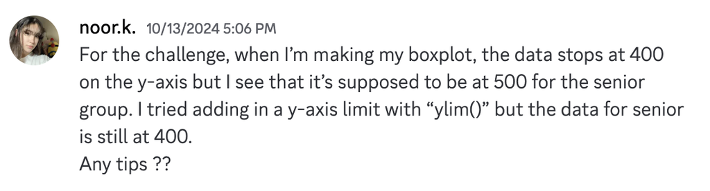

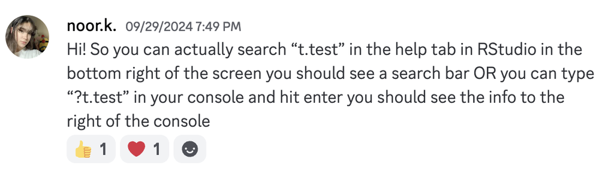

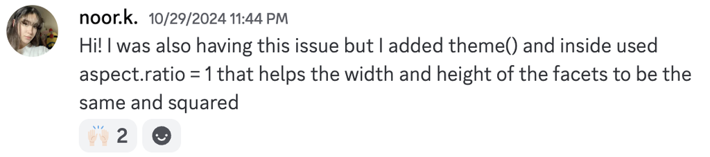

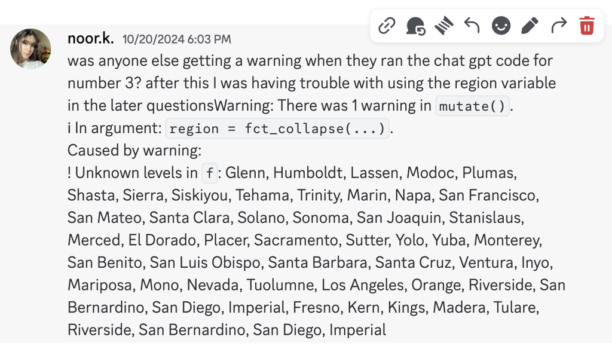

I think the Discord chat is awesome! I realized that even people asking questions they have indirectly helped me because sometimes it was the same question I had. Acknowledging the usefulness of the chat I became more comfortable with asking any questions I had, knowing they can possibly help someone else. I also am very empathetic and am a student like everyone else so I understand the frustration of being confused with some of the material, so whenever I can and have a valid answer to give I try and respond to others because I know how much I would have appreciated it if I was in their place. So above are a few times I collaborated in the chat.

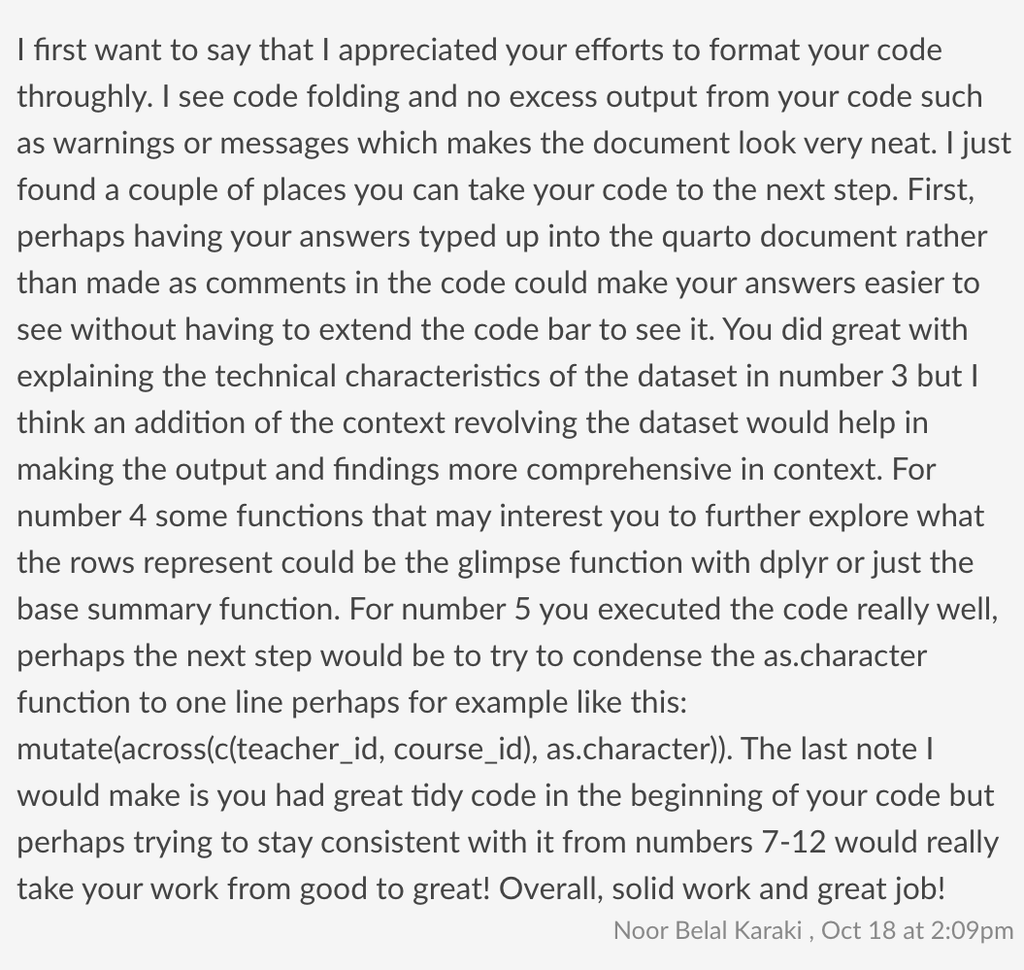

I think feedback is one of the biggest ways we learn code because it’s mostly likely not the case that I will read something once and automatically understand it. I believe that a lot of the true growth in learning is through making mistakes and going back to review what went wrong. The feedback I get on the homework helps guide me to be more successful just as the peer code reviewing does. Knowing how powerful this is I give my full attention and thoughtfulness when writing my code reviews for my peers, I am proud of all the reviews I have done but the one above in particular because of the time I spent on it.

A really big personal moral of mine is to always treat others with kindness and care. As a collaborator I think I did a good job of being supportive and welcoming, throughout the course being with different pairs every week helped my comfortably grow with voicing my ideas to new people. I have had great experiences with all the partners I had throughout the course, as I felt that team success and learning were my priorities.